# Práctica 02

Ignacio Ruiz de Zuazu Echevarría

7/11/2020

[link a GitHub](https://github.com/ignacio-ruiz-de-zuazu/Prediccion-practicas.git)

[figure not shown]

## Objetivo del trabajo

El objetivo de este trabajo es el de encontrar un modelo capaz de predecir el salario de un jugador de la NBA a partir de una serie de variables que vendrán definidas en el dataset de la NBA. A partir de modelos de regresión lineal encontraremos las variables más relevantes que definen el salario de un jugador a la hora de realizar una predicción con el menor error posible. Se utilizarán las técnicas de cross validation y regularización para seleccionar el mejor modelo desde un punto de vista predictivo.

## Librerías

```r
library(here) # Comentar
library(tidyverse)
library(janitor) # Clean names
library(skimr) # Beautiful Summarize
library(magrittr) # Pipe operators
```

```r
library(corrplot) # Correlations
library(ggcorrplot)  # Correlations
library(PerformanceAnalytics) # Correlations
library(leaps) # Model selection
library(rsample)  # data splitting
library(glmnet)   # implementing regularized regression approaches
library(dplyr)
library(ggplot2)
```

### Dataset

```r
nba <-  read.csv("./data/nba.csv")
head(nba)
```

```
##          Player   Salary NBA_Country NBA_DraftNumber Age  Tm  G   MP  PER   TS.
## 1       Zhou Qi   815615       China              43  22 HOU 16   87  0.6 0.303
## 2 Zaza Pachulia  3477600     Georgia              42  33 GSW 66  937 16.8 0.608
## 3 Zach Randolph 12307692         USA              19  36 SAC 59 1508 17.3 0.529
## 4   Zach LaVine  3202217         USA              13  22 CHI 24  656 14.6 0.499
## 5  Zach Collins  3057240         USA              10  20 POR 62  979  8.2 0.487
## 6  Yogi Ferrell  1312611         USA              62  24 DAL 79 2238 11.5 0.543
##   X3PAr   FTr ORB. DRB. TRB. AST. STL. BLK. TOV. USG.  OWS DWS   WS  WS.48
## 1 0.593 0.370  6.5 16.8 11.7  1.5  1.1  6.8 18.2 19.5 -0.4 0.1 -0.2 -0.121
## 2 0.004 0.337 11.0 25.0 18.5 15.4  1.9  1.3 19.3 17.2  1.7 1.4  3.1  0.160
## 3 0.193 0.140  7.0 23.8 15.0 14.9  1.4  0.6 12.5 27.6  0.3 1.1  1.4  0.046
## 4 0.346 0.301  1.4 14.4  7.7 18.6  1.8  0.5  9.7 29.5 -0.1 0.5  0.4  0.027
## 5 0.387 0.146  4.9 18.3 11.7  7.3  0.8  2.5 15.6 15.5 -0.4 1.2  0.8  0.038
## 6 0.489 0.141  1.3 11.3  6.1 13.3  1.4  0.3  9.1 17.0  1.6 1.6  3.1  0.067
##    OBPM DBPM   BPM VORP
## 1 -10.6  0.5 -10.1 -0.2
## 2  -0.6  1.3   0.8  0.7
## 3  -0.6 -1.3  -1.9  0.0
## 4  -0.7 -2.0  -2.6 -0.1
## 5  -3.7  0.9  -2.9 -0.2
## 6  -0.4 -0.5  -0.9  0.6
```

```r
nba %<>% clean_names()
```

### Análisis Descriptivo

- Variables

```r
colnames(nba)
```

```
##  [1] "player"           "salary"           "nba_country"      "nba_draft_number"
##  [5] "age"              "tm"               "g"                "mp"
##  [9] "per"              "ts"               "x3p_ar"           "f_tr"
## [13] "orb"              "drb"              "trb"              "ast"
## [17] "stl"              "blk"              "tov"              "usg"
## [21] "ows"              "dws"              "ws"               "ws_48"
## [25] "obpm"             "dbpm"             "bpm"              "vorp"
```

- Detección de duplicados

```r
nba %<>% distinct(player,.keep_all = TRUE)
```

- Eliminación de NA

```r
nba %<>% drop_na()
```

- Summary

```r
skim(nba)
```

Data summary

| Name | nba |
| --- | --- |
| Number of rows | 481 |
| Number of columns | 28 |
| _______________________ |  |
| Column type frequency: |  |
| character | 3 |
| numeric | 25 |
| ________________________ |  |
| Group variables | None |

**Variable type: character**

| skim_variable | n_missing | complete_rate | min | max | empty | n_unique | whitespace |
| --- | --- | --- | --- | --- | --- | --- | --- |
| player | 0 | 1 | 7 | 24 | 0 | 481 | 0 |
| nba_country | 0 | 1 | 3 | 16 | 0 | 44 | 0 |
| tm | 0 | 1 | 3 | 3 | 0 | 31 | 0 |

**Variable type: numeric**

| skim_variable | n_missing | complete_rate | mean | sd | p0 | p25 | p50 | p75 | p100 | hist |
| --- | --- | --- | --- | --- | --- | --- | --- | --- | --- | --- |
| salary | 0 | 1 | 6682859.45 | 7405536.17 | 46080.00 | 1471382.00 | 3290000.00 | 1.00e+07 | 34682550.00 | ▇▂▁▁▁ |
| nba_draft_number | 0 | 1 | 29.29 | 21.10 | 1.00 | 10.00 | 24.00 | 4.70e+01 | 62.00 | ▇▅▃▃▆ |
| age | 0 | 1 | 26.29 | 4.27 | 19.00 | 23.00 | 26.00 | 2.90e+01 | 41.00 | ▇▇▆▂▁ |
| g | 0 | 1 | 50.52 | 24.67 | 1.00 | 30.00 | 59.00 | 7.10e+01 | 79.00 | ▃▂▂▃▇ |
| mp | 0 | 1 | 1163.17 | 808.61 | 1.00 | 391.00 | 1155.00 | 1.83e+03 | 2898.00 | ▇▅▆▅▂ |
| per | 0 | 1 | 13.36 | 8.74 | -41.10 | 9.90 | 13.30 | 1.66e+01 | 134.10 | ▁▇▁▁▁ |
| ts | 0 | 1 | 0.54 | 0.11 | 0.00 | 0.51 | 0.54 | 5.80e-01 | 1.50 | ▁▇▂▁▁ |
| x3p_ar | 0 | 1 | 0.34 | 0.23 | 0.00 | 0.17 | 0.35 | 4.80e-01 | 1.00 | ▇▇▇▂▁ |
| f_tr | 0 | 1 | 0.26 | 0.30 | 0.00 | 0.16 | 0.23 | 3.20e-01 | 5.33 | ▇▁▁▁▁ |
| orb | 0 | 1 | 4.91 | 4.58 | 0.00 | 1.80 | 3.30 | 7.10e+00 | 35.90 | ▇▂▁▁▁ |
| drb | 0 | 1 | 15.03 | 6.80 | 0.00 | 10.30 | 14.00 | 1.88e+01 | 37.60 | ▂▇▅▂▁ |
| trb | 0 | 1 | 9.97 | 4.93 | 0.00 | 6.20 | 8.70 | 1.33e+01 | 26.50 | ▂▇▃▂▁ |
| ast | 0 | 1 | 12.96 | 9.09 | 0.00 | 6.90 | 9.90 | 1.72e+01 | 49.40 | ▇▅▂▁▁ |
| stl | 0 | 1 | 1.54 | 0.99 | 0.00 | 1.00 | 1.50 | 1.90e+00 | 12.50 | ▇▁▁▁▁ |
| blk | 0 | 1 | 1.72 | 1.69 | 0.00 | 0.60 | 1.20 | 2.20e+00 | 13.40 | ▇▂▁▁▁ |
| tov | 0 | 1 | 13.12 | 6.12 | 0.00 | 9.90 | 12.50 | 1.56e+01 | 66.70 | ▇▆▁▁▁ |
| usg | 0 | 1 | 18.94 | 5.81 | 5.70 | 15.00 | 17.90 | 2.22e+01 | 45.10 | ▂▇▃▁▁ |
| ows | 0 | 1 | 1.29 | 1.88 | -2.30 | 0.00 | 0.80 | 2.00e+00 | 11.40 | ▇▇▂▁▁ |
| dws | 0 | 1 | 1.19 | 1.03 | 0.00 | 0.30 | 1.00 | 1.80e+00 | 5.60 | ▇▅▂▁▁ |
| ws | 0 | 1 | 2.48 | 2.67 | -1.20 | 0.40 | 1.90 | 3.60e+00 | 15.00 | ▇▅▁▁▁ |
| ws_48 | 0 | 1 | 0.08 | 0.16 | -1.06 | 0.04 | 0.08 | 1.20e-01 | 2.71 | ▁▇▁▁▁ |
| obpm | 0 | 1 | -1.22 | 5.02 | -36.50 | -2.60 | -1.00 | 4.00e-01 | 68.70 | ▁▇▁▁▁ |
| dbpm | 0 | 1 | -0.48 | 2.39 | -14.30 | -1.60 | -0.40 | 1.00e+00 | 6.80 | ▁▁▂▇▁ |
| bpm | 0 | 1 | -1.70 | 5.64 | -49.20 | -3.50 | -1.20 | 6.00e-01 | 54.40 | ▁▁▇▁▁ |
| vorp | 0 | 1 | 0.60 | 1.25 | -1.30 | -0.10 | 0.10 | 9.00e-01 | 8.60 | ▇▃▁▁▁ |

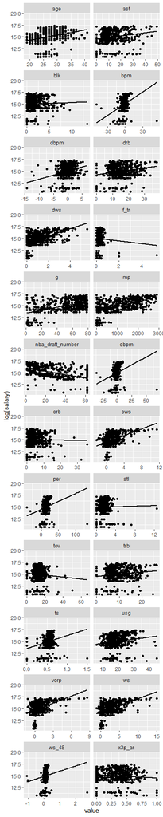

```r
nba %>%
  select_at(vars(-c("player","nba_country","tm"))) %>%
  tidyr::gather("id", "value", 2:25) %>%
  ggplot(., aes(y = log(salary), x = value)) +
  geom_point() +
  geom_smooth(method = "lm", se = FALSE, color = "black") +
  facet_wrap(~id,ncol = 2,scales = "free_x")
```

## Exploratory data analysis

Para la realización de los modelos y de nuestro estudio, transformamos la variable independiente y que pretendemos explicar como es el salario de un jugador NBA en logaritmo.

```r
nba_log <- nba %>% mutate(salary = log(salary))
```

También se eliminarán aquellas variables que desde un principio no vayan a explicar el comportamiento del salario como son los nombres de los jugadores, los países y los equipos de la NBA ya que cada equipo tiene un límite salarial.

```r
categoricas <- c("player","nba_country","tm")
```

Matriz de correlaciones

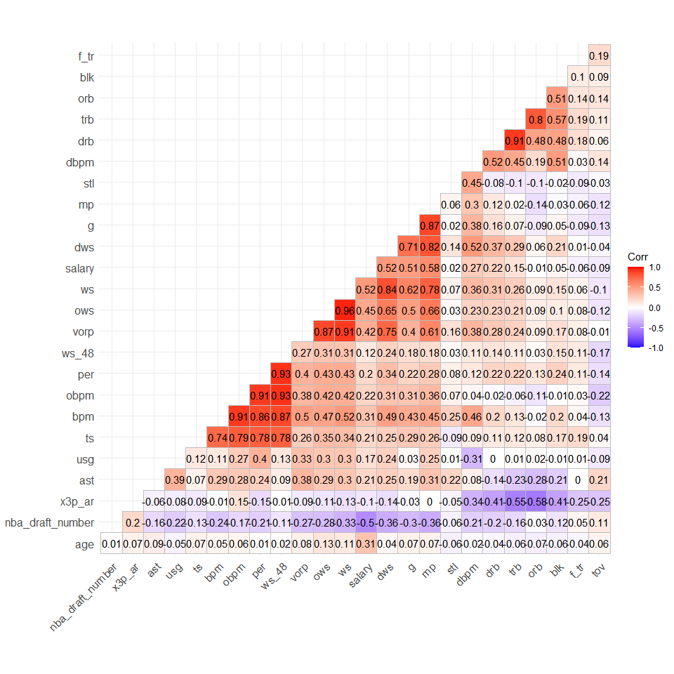

```r
ggcorrplot(cor(nba_log %>%
                 select_at(vars(-categoricas)),
               use = "complete.obs"),
           hc.order = TRUE,
           type = "lower",  lab = TRUE)
```

Observamos que las variables con más correlación son:

- Offensive Box Plus/Minus y Box Plus/Minus puesto que son variables que mantienen una relación en cuanto a las estadísticas.
- PER y Offensive Box Plus/Minus puesto que el PER engloba un conjunto de estadísticas entre las que se encuentra el Offensive Box Plus/Minus.
- Win Shares Per 48 Minutes y el PER puesto que el PER engloba un conjunto de estadísticas.
- Offensive Win shares y win shares

Las que menos correlación tienen son:

- 3-Point Attempt Rate Percentage y muchas de las estadísticas como los rebotes ya que normalmente los jugadores que tiran de 3 no tienen porque ser jugadores que cojan rebotes ya que normalmente se asocia los tiros de 3 a jugadores con estatura baja ocon un posición de base o escolta y que no tienen la obligación de cojer rebotes.

## Modelo de regresión lineal

```r
nba_sin_categoricas <- nba_log %>% dplyr::select(salary,age,nba_draft_number,
                                                           g:vorp)

regresion1 <- lm(salary~., data = nba_sin_categoricas)

summary(regresion1)
```

```
##
## Call:
## lm(formula = salary ~ ., data = nba_sin_categoricas)
##
## Residuals:
##     Min      1Q  Median      3Q     Max
## -3.6467 -0.5503  0.0338  0.6031  3.3476
##
## Coefficients:
##                    Estimate Std. Error t value Pr(>|t|)
## (Intercept)      10.6956949  0.9742269  10.979  < 2e-16 ***
## age               0.0994131  0.0112557   8.832  < 2e-16 ***
## nba_draft_number -0.0220520  0.0025411  -8.678  < 2e-16 ***
## g                -0.0050789  0.0049677  -1.022 0.307144
## mp                0.0010505  0.0002156   4.872 1.53e-06 ***
## per              -0.1836822  0.0558139  -3.291 0.001076 **
## ts                3.1723864  1.0240164   3.098 0.002069 **
## x3p_ar           -0.4079670  0.4691284  -0.870 0.384961
## f_tr             -0.2894332  0.1764599  -1.640 0.101649
## orb              -0.0764709  0.1799375  -0.425 0.671047
## drb              -0.0631515  0.1781392  -0.355 0.723123
## trb               0.2063443  0.3566004   0.579 0.563116
## ast               0.0157191  0.0094577   1.662 0.097192 .
## stl               0.0359938  0.0839434   0.429 0.668281
## blk               0.0106909  0.0632854   0.169 0.865925
## tov              -0.0210089  0.0104781  -2.005 0.045551 *
## usg               0.0728828  0.0208889   3.489 0.000532 ***
## ows              -0.1698247  0.8965631  -0.189 0.849850
## dws              -0.4168086  0.9017950  -0.462 0.644159
## ws                0.1753680  0.8975693   0.195 0.845182
## ws_48             6.1696386  2.3458492   2.630 0.008827 **
## obpm             -0.5601645  0.9469549  -0.592 0.554450
## dbpm             -0.5030567  0.9301535  -0.541 0.588888
## bpm               0.5825235  0.9337111   0.624 0.533019
## vorp              0.0274218  0.1260476   0.218 0.827876
## ---
## Signif. codes:  0 '***' 0.001 '**' 0.01 '*' 0.05 '.' 0.1 ' ' 1
##
## Residual standard error: 1.015 on 456 degrees of freedom
## Multiple R-squared:  0.5586, Adjusted R-squared:  0.5354
## F-statistic: 24.04 on 24 and 456 DF,  p-value: < 2.2e-16
```

Se observa a primera vista que muchas de las variables del modelo no resultan significativas con un error de 1.015 y un Adjusted R - squared de 53.54%.

```r
nba_sin_categoricas <- nba_log %>% dplyr::select(salary,age,nba_draft_number,
                                                           g:vorp)

regresion1 <- lm(salary~., data = nba_sin_categoricas)

summary(regresion1)
```

[output not shown]

```
##
## Call:
## lm(formula = salary ~ ., data = nba_sin_categoricas)
##
## Residuals:
##     Min      1Q  Median      3Q     Max
## -3.6467 -0.5503  0.0338  0.6031  3.3476
##
## Coefficients:
##                    Estimate Std. Error t value Pr(>|t|)
## (Intercept)      10.6956949  0.9742269  10.979  < 2e-16 ***
## age               0.0994131  0.0112557   8.832  < 2e-16 ***
## nba_draft_number -0.0220520  0.0025411  -8.678  < 2e-16 ***
## g                -0.0050789  0.0049677  -1.022 0.307144
## mp                0.0010505  0.0002156   4.872 1.53e-06 ***
## per              -0.1836822  0.0558139  -3.291 0.001076 **
## ts                3.1723864  1.0240164   3.098 0.002069 **
## x3p_ar           -0.4079670  0.4691284  -0.870 0.384961
## f_tr             -0.2894332  0.1764599  -1.640 0.101649
## orb              -0.0764709  0.1799375  -0.425 0.671047
## drb              -0.0631515  0.1781392  -0.355 0.723123
## trb               0.2063443  0.3566004   0.579 0.563116
## ast               0.0157191  0.0094577   1.662 0.097192 .
## stl               0.0359938  0.0839434   0.429 0.668281
## blk               0.0106909  0.0632854   0.169 0.865925
## tov              -0.0210089  0.0104781  -2.005 0.045551 *
## usg               0.0728828  0.0208889   3.489 0.000532 ***
## ows              -0.1698247  0.8965631  -0.189 0.849850
## dws              -0.4168086  0.9017950  -0.462 0.644159
## ws                0.1753680  0.8975693   0.195 0.845182
## ws_48             6.1696386  2.3458492   2.630 0.008827 **
## obpm             -0.5601645  0.9469549  -0.592 0.554450
## dbpm             -0.5030567  0.9301535  -0.541 0.588888
## bpm               0.5825235  0.9337111   0.624 0.533019
## vorp              0.0274218  0.1260476   0.218 0.827876
## ---
## Signif. codes:  0 '***' 0.001 '**' 0.01 '*' 0.05 '.' 0.1 ' ' 1
##
## Residual standard error: 1.015 on 456 degrees of freedom
## Multiple R-squared:  0.5586, Adjusted R-squared:  0.5354
## F-statistic: 24.04 on 24 and 456 DF,  p-value: < 2.2e-16
```

El VIF mide cuánto aumenta la varianza de un coeficiente de regresión estimado si sus predictores están correlacionados. A mayor variación nos resulatría un problema ya que buscamos estimaciones precisas. Si la varianza de los coeficientes aumenta, nuestro modelo no será fiable. El VIF también detecta problemas de multicolinealidad. Genera cambios muy grandes en los estimadores.

#### Selección del modelo

```r
nba_final <- nba_sin_categoricas # Empleamos todas las varaibles en un principio

set.seed(1234)
filas_data <- nrow(nba_final) # número de filas
num_data_test <- 10
train <-  sample(filas_data ,filas_data - num_data_test)


nba_train <- nba_sin_categoricas[train,] # data de entrenamiento
nba_test  <-  nba_sin_categoricas[-train,] # data para el test

seleccion_modelo <- regsubsets(salary~. , data = nba_train, method = "seqrep", nvmax = 20)

resumen_seleccion_modelo <- summary(seleccion_modelo)

data.frame(
  Adj.R2 = (resumen_seleccion_modelo$adjr2),
  CP = (resumen_seleccion_modelo$cp),
  BIC = (resumen_seleccion_modelo$bic)
)
```

```
##       Adj.R2         CP       BIC
## 1  0.3343986 197.010700 -180.4207
## 2  0.4290205 103.400334 -247.4933
## 3  0.4689934  64.478556 -276.5305
## 4  0.5197487  15.038921 -318.7043
## 5  0.5198819  15.885572 -313.6920
## 6  0.5195917  17.150815 -308.2664
## 7  0.5247299  13.068604 -308.1925
## 8  0.5282683  10.580383 -306.5757
## 9  0.5296188  10.252640 -302.7918
## 10 0.5314565   9.453954 -299.5035
## 11 0.5196195  22.014259 -282.6224
## 12 0.5336976   9.277353 -291.5043
## 13 0.5359619   8.084398 -288.6717
## 14 0.5368847   8.202266 -284.4861
## 15 0.5211708  24.425576 -263.6490
## 16 0.5365726  10.533536 -273.9294
## 17 0.5357785  12.312904 -268.0068
## 18 0.5349564  14.115848 -262.0595
## 19 0.5182523  31.151311 -240.3265
## 20 0.5336593  17.379042 -250.5266
```

BIC nos muestra los mejores modelos según el número de variables. Cuando cambiamos neustro `set.seed` surgen resultados distintos para una misma muestra.

```r
data.frame(
  Adj.R2 = which.max(resumen_seleccion_modelo$adjr2),
  CP = which.min(resumen_seleccion_modelo$cp),
  BIC = which.min(resumen_seleccion_modelo$bic)
)
```

```
##   Adj.R2 CP BIC
## 1     14 13   4
```

Por ejemplo, si escogemos el criterio de BIC nos encontraremos con el siguiente modelo

```r
coef(seleccion_modelo,which.min(resumen_seleccion_modelo$bic))
```

```
##      (Intercept)              age nba_draft_number               mp
##    11.7177685858     0.0995664958    -0.0226718307     0.0007887849
##              drb
##     0.0245851796
```

Esta es una forma de elegir un modelo dependiendo del criterio que se elija pero para este trabajo se utilizarán las técnicas de cross validation y regularización para seleccionar el mejor modelo desde un punto de vista predictivo.

## Mediante Ridge

En primer lugar, creamos matrices de los modelos de funciones y vectores de respuesta de entrenamiento y de prueba.

```r
nba_train_x <- model.matrix(salary ~ ., nba_train)[, -1]
nba_train_y <- nba_train$salary

nba_test_x <- model.matrix(salary ~ ., nba_test)[, -1]
nba_test_y <- nba_test$salary
```

Para realizar un regresión cresta podemos usar la función glmnet :: glmnet. El parámetro alpha le dice a glmnet que realice una regersión cresta (alpha = 0).

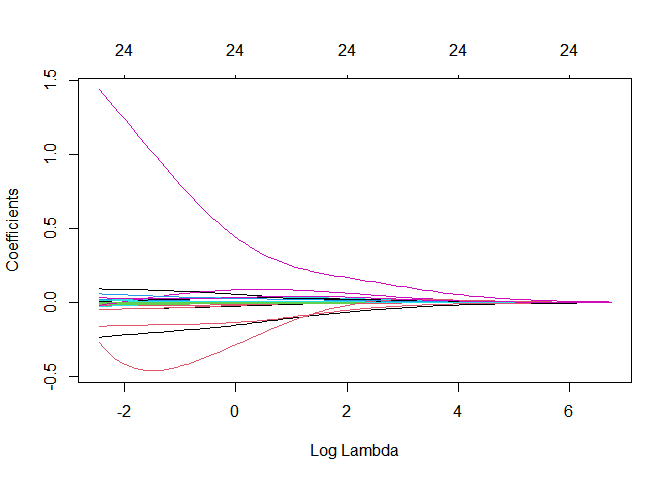

```r
nba_ridge <- glmnet(
  x = nba_train_x,
  y = nba_train_y,
  alpha = 0 # Ridge
)

plot(nba_ridge, xvar = "lambda")
```

```r
nba_ridge$lambda %>% head()
```

```
## [1] 855.6412 779.6284 710.3684 647.2612 589.7603 537.3676
```

## Mediante Lasso

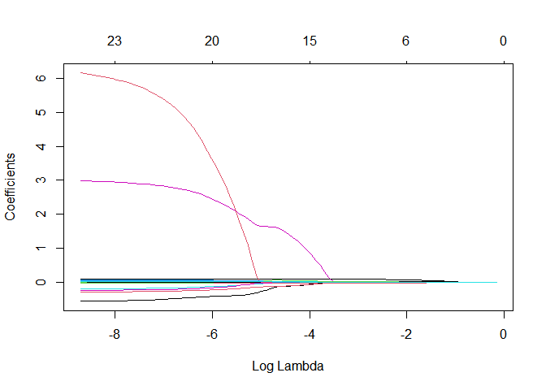

```r
nba_lasso <- glmnet(
  x = nba_train_x,
  y = nba_train_y,
  alpha = 1
)

plot(nba_lasso, xvar = "lambda")
```

### Mediante Cross-Validation

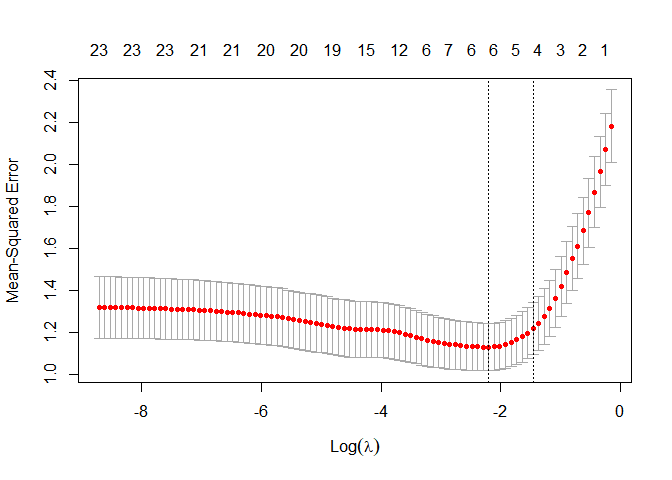

```r
nba_lasso_cv <- cv.glmnet(
  x = nba_train_x,
  y = nba_train_y,
  alpha = 1
)

plot(nba_lasso_cv)
```

```r
min(nba_lasso_cv$cvm)
```

```
## [1] 1.128841
```

Este es el criterio que se seguirá para elegir el modelo más preciso

### Elastic Net (Red elástica)

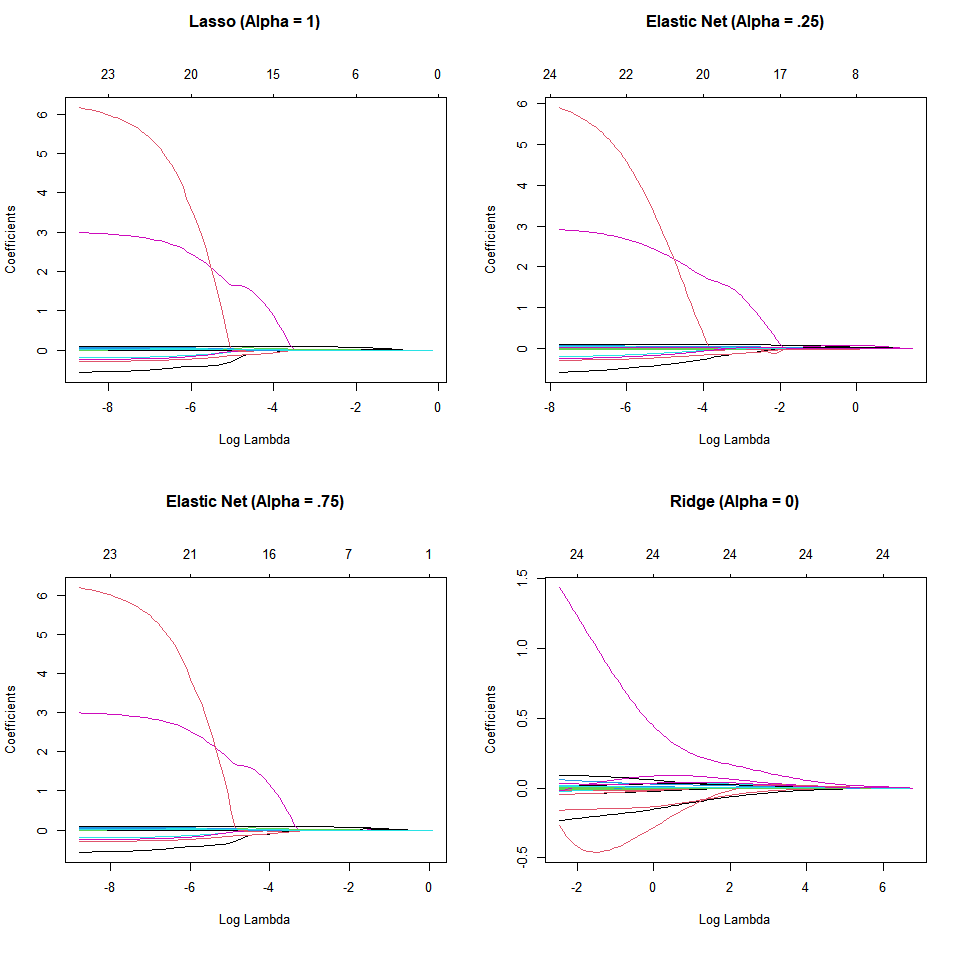

A continuación encontraremos el alpha óptimo para un MSE mínimo junto con su lambda.

```r
for(i in seq_along(nba_grid$alpha)) {


  fit <- cv.glmnet(nba_train_x, nba_train_y, alpha = nba_grid$alpha[i], foldid = nba_id)


  nba_grid$mse_min[i]    <- fit$cvm[fit$lambda == fit$lambda.min]
  nba_grid$mse_1se[i]    <- fit$cvm[fit$lambda == fit$lambda.1se]
  nba_grid$lambda_min[i] <- fit$lambda.min
  nba_grid$lambda_1se[i] <- fit$lambda.1se
}

nba_grid
```

```
## # A tibble: 11 x 5
##    alpha mse_min mse_1se lambda_min lambda_1se
##    <dbl>   <dbl>   <dbl>      <dbl>      <dbl>
##  1   0      1.13    1.20     0.238       1.27
##  2   0.1    1.12    1.20     0.300       0.917
##  3   0.2    1.11    1.18     0.199       0.606
##  4   0.3    1.10    1.17     0.145       0.444
##  5   0.4    1.09    1.17     0.120       0.365
##  6   0.5    1.09    1.17     0.105       0.321
##  7   0.6    1.09    1.16     0.0960      0.267
##  8   0.7    1.09    1.16     0.0823      0.229
##  9   0.8    1.08    1.16     0.0790      0.220
## 10   0.9    1.08    1.16     0.0703      0.196
## 11   1      1.08    1.15     0.0632      0.176
```

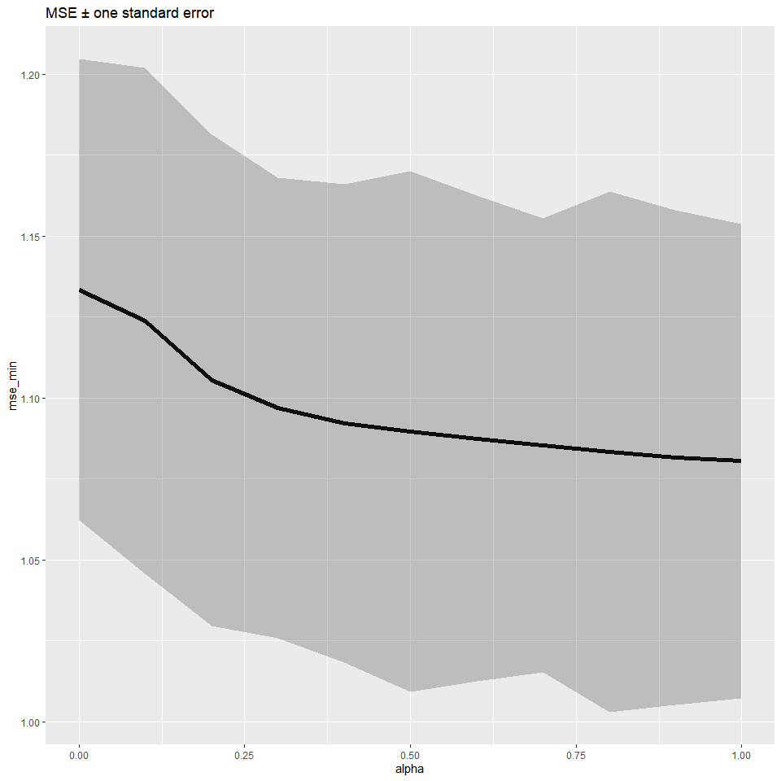

```r
nba_grid %>%
  mutate(se = mse_1se - mse_min) %>%
  ggplot(aes(alpha, mse_min)) +
  geom_line(size = 2) +
  geom_ribbon(aes(ymax = mse_min + se, ymin = mse_min - se), alpha = .25) +
  ggtitle("MSE ± one standard error")
```

```r
# mejor modelo
cv_net   <- cv.glmnet(nba_train_x, nba_train_y, alpha = 0.9)
min(cv_net$cvm)
```

```
## [1] 1.106449
```

```r
# predicción
pred <- predict(cv_net, s = cv_net$lambda.min, nba_test_x)
mean((nba_test_y - pred)^2)
```

```
## [1] 1.18565
```

#### Modelo sin variables con multicolinealidad

```r
variables <- c('mp', 'per', 'orb', 'drb', 'trb', 'ows', 'dws', 'ws', 'ws_48', 'obpm', 'dbpm', 'bpm', 'vorp')

nba_final2 <- nba_sin_categoricas %>% select_at(vars(-variables))
```

```
## Note: Using an external vector in selections is ambiguous.
## i Use `all_of(variables)` instead of `variables` to silence this message.
## i See <https://tidyselect.r-lib.org/reference/faq-external-vector.html>.
```

```r
set.seed(1234)
filas_data <- nrow(nba_final2) # número de filas
num_data_test <- 10
train <-  sample(filas_data ,filas_data - num_data_test)


nba_train <- nba_sin_categoricas[train,] # data de entrenamiento
nba_test  <-  nba_sin_categoricas[-train,] # data para el test
```

```r
for(i in seq_along(nba_grid$alpha)) {


  fit <- cv.glmnet(nba_train_x, nba_train_y, alpha = nba_grid$alpha[i], foldid = nba_id)


  nba_grid$mse_min[i]    <- fit$cvm[fit$lambda == fit$lambda.min]
  nba_grid$mse_1se[i]    <- fit$cvm[fit$lambda == fit$lambda.1se]
  nba_grid$lambda_min[i] <- fit$lambda.min
  nba_grid$lambda_1se[i] <- fit$lambda.1se
}

nba_grid
```

[output not shown]

# Conclusiones

Tras realizar este trabajo, se llega a la conclusión de que los distintos modelos elaborados para predecir el salario de un jugador mantienen un error bastante elevado al igual que ocurría en el anterior trabajo. Se podrían realizar más modelos, como en el anterior trabajo, seleccionando los datos que aporten información al estudio ya que hay jugadores que apenas han tenido minutos en toda la temporada y también hay variables como la edad que se podría valorar como una variable polinomica ya que podriamos suponer que cuando un jugador empieza su carrera en la NBA tiene un salario fijo y a medida que van aumentando sus años de experiencia este sueldo es donde podría variar.